# Lecture notes 23

Tryggvi Jónsson

# Content Outline

Recursive and adaptive estimation:

- Introduction to Chapter 11
- Recursive LS, Section 11.1

# Why recursive and adaptive estimation?

- As time passes we get more information
- Models are approximations
- The best approximation change over time
- Makes it possible to produce software which learns as new data becomes available

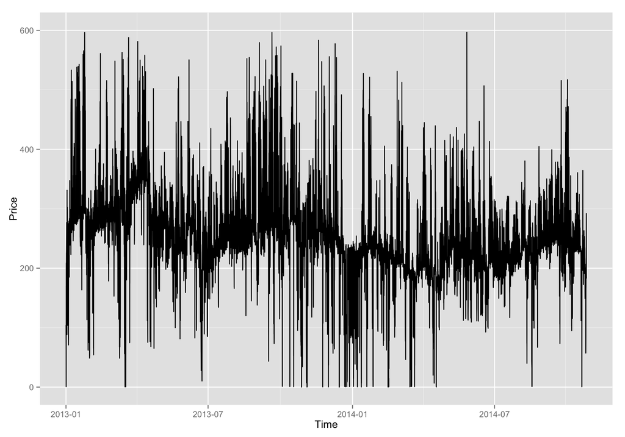

# Types of models considered

REG:

$Y_t = µ + β_1U_{1,t} + β_2U_{2,t} + \ldots + β_mU_{m,t} + ε_t$

FIR:

$\begin{aligned} Y_t &= µ + ω(B)U_t + εt\\ &= µ + ω_0U_t + ω_1U_{t−1} + \ldots + ω_sU_{t−s} + ε_t \end{aligned}$

AR:

$\begin{aligned} φ(B)Y_t &= µ + ε_t ⇔ \\ Y_t &= µ − φ_1Y_{t−1} − φ_2Y_{t−2} − \ldots − φ_pY_{t−p}+ ε_t \end{aligned}$

ARX:

$\begin{aligned} φ(B)Y_t &= µ + ω(B)U_t + ε_t ⇔ \\ Y_t &= µ − φ_1Y_{t−1} − \ldots − φ_pY_{t−p}\\ &+ ω_0U_t + \ldots + ω_sU_{t−s} + ε_t \end{aligned}$

# Generic form of the models considered

$Y_t = \mathbf x^T_tθ + ε_t = θ_1x_{1,t} + θ_2x_{2,t} + \ldots + θ_nx_{p,t} + ε_t$

Example:

$Y_t = μ \cdot \underbrace{1}_{x_{1,t}} + φ_2\cdot \underbrace{(−Y_{t−2})}_{x_{2,t}} + ω_1 \cdot \underbrace{U_{t−1}}_{x_{3,t}}+ ε_t$

# LS-estimate at time t

Model:

$Y_t = x^T_t θ + ε_t$

Data (x may contain lagged values of the “real” input):

$Y_1, Y_2, Y_3, Y_4, \ldots , Y_{t−1}, Y_t\\ x_1,x_2,x_3,x_4, \ldots ,x_{t−1},x_t$

LS-estimate based on t observations:

$\begin{aligned} \widehat{\mathbf θ}_t &= \operatorname*{arg\,min}_{\widehat{\theta}} S_t(\mathbf θ) = (\mathbf X^T\mathbf X)^{−1}\mathbf X^T\mathbf Y\\ S_t(\mathbf θ) &= \sum^t_{s=1} (Y_s − \mathbf x^T_s \mathbf θ)^2 \end{aligned}$